# Financial network analysis in R

A new package that gets it right

Fabio Ashtar Telarico* University of Ljubljana, FDV *Fabio-Ashtar.Telarico@fdv.uni-lj.si

CRAN version 1.0 (Thu May 25, 2023)

# 1 Introduction

There are a number of package helping users to deal with network data in `R`, most notably [`network`](https://statnet.org/) and [`igraph`](https://igraph.org/). However, these very popular R packages do not offer specific tools for working with financial networks. Yet, this is one of the frontiers of network-analysis and its application to economics (see [Haberley and Wojcik 2022](https://doi.org/10.1093/oso/9780198870982.003.0001))

For years now, authors and analysts have worked on financial data using *ad-hoc* tools or programming languages other than `R`. So, the package `FinNet` was born to provide all `R` users with the ability to study financial networks with a set of tool especially designed to this purpose. Specifically, `FinNet` offers both brand new tools and an interface to the almost limitless capabilities of `igraph` and `network`.

The first release of `FinNet` on both CRAN and GitHub introduces the backbone of this system, which will be expanded with new releases.

# 2 Motivation

Before `FinNet` there was not `R` package especially conceived for financial-network analysis on the `CRAN`. True, similar results could be achieved combining functions from several packages. However, `FinNet` allows users (mainly analysts and researchers) to focus on what matters, their analyses, and let the package take care of tedious operations and conversion.

In a nutshell, `FinNet` is designed to put ease of use first.[^1] Moreover, it allows for a very lean installation since the only required packages are included with base `R`: `grDevices` and `methods`. Yet, it is extremely flexible insofar as it allows users to leverage the capabilities of other packages available on `CRAN`:

- [`igraph`](https://CRAN.R-project.org/package=igraph) or [`network`](https://CRAN.R-project.org/package=network) to interface `FinNet` with these packages;
- [`knitr`](https://CRAN.R-project.org/package=knitr) or [`pander`](https://CRAN.R-project.org/package=pander) to print better summaries to the console;
- [`Matrix`](https://CRAN.R-project.org/package=Matrix) to optimise the storage of relations between agents;
- [`SPB`](https://CRAN.R-project.org/package=SPB) to get better progress bars; and
- [`yahoofinancer`](https://CRAN.R-project.org/package=yahoofinancer) to automatically retrieve data from [Yahoo! Finance](https://finance.yahoo.com/)

## 2.1 Simplifying complex workflows

For instance, one may be tempted to use `yahoofinancer` to retrieve financial data, [`tibble`](https://CRAN.R-project.org/package=tibble) to store the relations between agents before converting them into a `network` object and [`sna`](https://CRAN.R-project.org/package=sna) to run network-analytic tasks. However, this workflow would force users to deal with incompatible paradigms (e.g., `yahoofinancer` uses object-oriented programming, whereas `igraph` and `sna` implement procedural programming).

By contrast, `FinNet` is coherently written in following a single paradigm and a uniform style.

## 2.2 Extending code’s life

Indeed, sometimes these issues can only be solved by relying on non-`CRAN` packages (such as [`yfR`](https://github.com/ropensci/yfR)). But mix-and-matching more packages exposes scripts to the risk of becoming partly unusable – especially if using non-`CRAN` packages.

For instance, many scripts employing the popular `quantmod` [need rewriting](https://github.com/joshuaulrich/quantmod/issues/221) due to the discontinuation of the API that the package used to access Google Finance after the latter’s ‘[renovation](https://web.archive.org/web/20180109152036/https://finance.google.com/finance?hl=en&tab=ee)’.

Meanwhile, `BatchgetSymbols` - launched in 2016 and very popular - [may be moribound](https://www.r-bloggers.com/2022/03/new-r-package-yfr/) due to the introduction of `yfR`.

Thus, users cannot overlook the risk of having their carefully constructed data-to-network pipeline disrupted by the discontinuation or failure of one of its basic packages either. But with `FinNet`, the death of one of the underlying packages will not affect final users. As long as a replacement is available, an update to the package can keep all functions alive and the use of ad-hoc classes ensures backward compatibility.

## 2.3 Stop worrying about memory management

Moreover, memory management becomes an issue while iterating over tens or even hundreds of thousands of agents or duplicating information about the agents and their relations across several formats (e.g., a large list of vector, a tibble, and a graph).

By contrast, `FinNet`’s built-in classes make a smart use of the package `Matrix` to reduce memory usage for storage and iteration. Moreover, the final relational-data object retains enough information to allow users to reconstruct all information about the agents without having to keep multiple copies of the same data in different formats.

# 3 Features

At this stage of development, `FinNet` provides the following:

- Specialised S4 classes for financial agents (`firm`), their relations (`financial_matrix`), and interfaces to other packages (`network_financial` and `igraph_financial`);
- Functions to register information about financial agents, including retrieving them from Yahoo! Finance;
- Function to encode the relations between these agents and their owners or managers into incidence matrices;
- Function to encode the relations between these agents (based on common ownership, board interlocks, or both) into adjacency matrices;
- Function to encode the relations between these agents (based on common ownership, board interlocks, or both) into extended `network` or `igraph` objects.

## 3.1 Classes

### 3.1.1 firm

A `firm` object represents an agent (most often a firm or other legal person) as a financial entity. It has the following attributes:

- *name* Name of the firm;
- *id* an unique ID, usually its ticker;
- *legal_form* Legal form of the firm;
- *sector* Sector in which the firm operates;
- *sector_classif* Activity sector classification (if any);
- *revenues* Yearly revenues;
- *capitalisation* Firm’s capitalisation;
- *management* Names of the members of the board;
- *ownership* Names of the owner(s);
- *shares* Share owned by (each of) the owner(s);
- *currency* Currency in which the capitalisation and revenues are expressed.

All of them, except `name`, can be `NA`.

The class has methods for `methods::show` and `print` that return an articulate summary

```
## A JSC with total revenue totalling USD41,867,800,000 and a capitalisation of USD45,401,317,376.
##                 >----------------------------------------------<
##
## Its managers are: Mary T. Barra, Mark L. Reuss, Paul A. Jacobson, Stephen K. Carlisle, Douglas L. Parks, Wayne Gilbert West, Christopher T. Hatto, Kent E. Helfrich, Fred  Killeen, Ashish  Kohli C.F.A..
##                 >----------------------------------------------<
##
## Ownership structure[1] "|Owner                                  |Share                                  |"
```

The package also offers methods to coerce other classes into `firm` (see below).

### 3.1.2 financial_matrix

A`financial_matrix` object contains an adjacency matrix represent the relations between firms (legal person) based on common ownership, board interlocks, or both. It comprises the following information:

- *M* Adjacency matrix
- *relation* Relations represented by the matrix
- *legal_form* Legal form of the firms
- *sector* Sector in which the firms operate
- *revenues* Yearly revenues
- *capitalisation* Firms’ capitalisation
- *currency* Currency in which the capitalisation and revenues are expressed.

The class has methods for several generic functions:

1. `methods::show`…

```
## Common ownership between 47 firms.
##
## Total capitalisation (data denominated in USD): 4180784640
## Total capitalisation (data denominated in BRL): 100672348160
## Total capitalisation (data denominated in GBP): 8.057793e+12
##
##
## Average revenues (data denominated in USD): 580730000
## Average revenues (data denominated in BRL): 0
## Average revenues (data denominated in GBP): 16346394889
##
##
##       DVA KHC OXY AXP LSXMA LSXMK
## DVA   0.0 0.5 0.5 0.5   0.2   0.2
## KHC   0.5 0.0 0.5 0.5   0.1   0.1
## OXY   0.5 0.5 0.0 0.6   0.2   0.2
## AXP   0.5 0.5 0.6 0.0   0.2   0.2
## LSXMA 0.2 0.1 0.2 0.2   0.0   0.7
## LSXMK 0.2 0.1 0.2 0.2   0.7   0.0
## * Only the first six firms shown
```

2. `print()`
3. `rownames()` and `colnames()`
4. `duplicated()`
5. `isSymmetric()`
6. `summary()`
7. `subset()`, which subset also non-matrix attributes
8. `unique()`, which extract unique elements from non-matrix attributes, too;
9. `ncol()` and `nrow()`, which check whether the attributes of the FF are of the right length given the number of columns/rows.

Furthermore, objects of class `financial_matrix` can be coerced to a list of objects of class `firm` using:

```
## firms <- as.firm(mat)
```

```
## The number of rows of the FF matrix was: 47
```

```
## The number of firms after coercion is: 47
```

## 3.2 Example workflow

### 3.2.1 From retrieving the data to an `igraph`/`sna` object

After having identified the firms of interest, the package can fetch all information on them as long as `yahoofinancer` is available. So:

```r
# Check if `yahoofinancer` is installed
isTRUE(requireNamespace('yahoofinancer', quietly = TRUE))
```

```
## [1] TRUE
```

```r
# Create a list of the desired firms
# Note: if `SPB` is installed, a progress bar will appear
firms <- find.firms(tickers = c('TM', 'GM', 'F', 'HMC'),
                    name = c('Toyota', 'General Motors',
                             'Ford', 'Honda'))
```

```
##
## Progress status: 1/4
##  [==================------------------------------------------------------]  25%
##
## Progress status: 2/4
##  [====================================------------------------------------]  50%
##
## Progress status: 3/4
##  [======================================================------------------]  75%
##
## Progress status: 4/4
##  [=========================================================================]  100%
```

```r
# Identify common-ownership relations in a firm-firm matrix
FF <- FF.norm.ownership(firms)

# Create a simple-looking graph
g <- FF.graph(FF, aesthetic = 'simple')
```

Some check using the S3 methods implemented for `financial_matrix` objects and the extension of some `igraph` functions allow to verify the correctness of the graph:

```r
# The order of the graph equals the number of rows in the FF matrix
vcount_fin(g) == nrow(FF)
```

```
## [1] TRUE
```

```r
# The names of its vertex match the row names of the FF matrix
V_fin(g)$name == rownames(FF)
```

```
## [1] TRUE TRUE TRUE TRUE
```

### 3.2.2 Plotting using default *nice* aesthetics

There are also useful defaults for a visual inspection of the network.

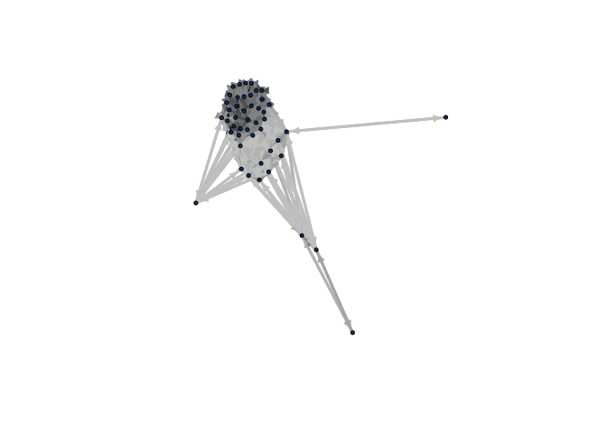

```r
# Load dataset
data('firms_BKB')

# Identify common-ownership relations in a firm-firm matrix
FF <- FinNet::FF(firms_BKB, who = 'own',
                 ties = 'naive', Matrix = TRUE)

# Create a nice-looking graph
g <- FF.graph(FF, aesthetic = 'nice')

# Plot it
plot_igraph_fin(g, vertex.label = NA, edge.arrow.size = .6, scale_vertex = 10)
```

# 4 Comparison with potentially similar `R` packages

[^1]: See full documentation: here.